# GMSE ongoing analysis

Matt Nuttall

30/10/20

This is a summary of my ongoing GMSE analysis which will investigate the social-ecological dynamics surrounding land tenure in a hypothetical conservation landscape that is loosely based on a Cambodian protected area.

As discussed, I have started simple and will build complexity as I go.

I have started with managers wanting to preserve all trees, but having very little power to set policy. In later simulations I have increased the manager budget a bit, and then started increasing manager budgets to see where the threshold for reducing clearance is.

## Simulation 0 (ten_rep_0)

Here I have set res_consume = 0. I wanted to start with the presence of trees on a cell not impacting yield at all, i.e. to remove any incentive for the users to clear forest. Although Brad has since confirmed that when land_ownership = FALSE then the users are essentially hunters and will try to cull as much as possible regardless of the effect of trees on yield.

Model set up:

```
## [1] "Initialising simulations ... "
## [1] "Generation  1 of  40"
## [1] "Generation  2 of  40"
## [1] "Generation  3 of  40"
## [1] "Generation  4 of  40"
## [1] "Generation  5 of  40"
## [1] "Generation  6 of  40"
## [1] "Generation  7 of  40"
## [1] "Generation  8 of  40"
## [1] "Generation  9 of  40"
## [1] "Generation  10 of  40"
## [1] "Generation  11 of  40"
## [1] "Generation  12 of  40"
## [1] "Generation  13 of  40"
## [1] "Generation  14 of  40"
```

[output cut: 26 more lines]

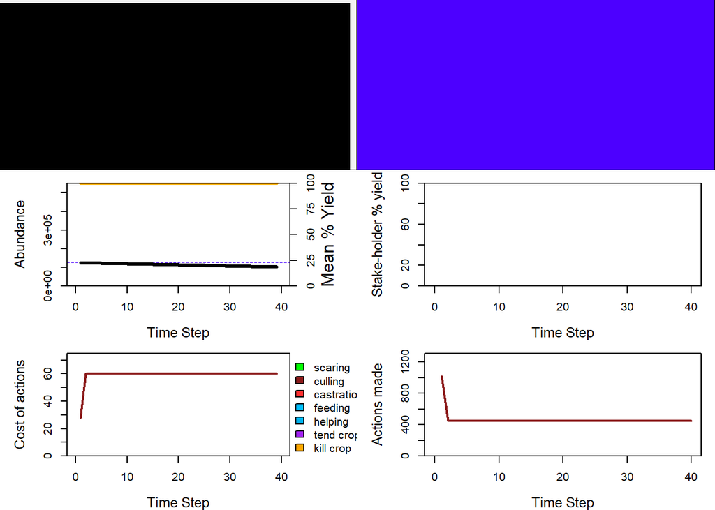

```r
ten_rep_0 <- gmse(
  time_max = 40,
  land_dim_1 = 50,
  land_dim_2 = 50, # landscape is 2500ha or 25km2
  res_movement = 0, # trees don't move
  remove_pr = 0, # Assume no death
  lambda = 0, # assume no growth
  agent_view = 10, # distance (cells) agent can see (currently only manager during obs process)
  agent_move = 50, # distance (cells) agents can travel (mostly affects managers during obs process)
  res_birth_K = 1, # must be positive value, but I want it small i.e. no real recruitment
  res_death_K = 500000, # carrying capacity set to way above starting number of resources
  res_move_type = 0, # 0=no move,
  res_death_type = 1, # 1=density-independent
  observe_type = 0, # 0=density-based sampling
  times_observe = 1, # observes once
  obs_move_type = 1, # uniform in any direction
  res_min_age = 0, # age of resources before agents record/act on them
  res_move_obs = FALSE, # trees don't move
  plotting = FALSE,
  res_consume = 0, # trees have no impact on yield

  # all genetic algorithm parameters left to default

  move_agents = TRUE, # should agents move at the end of each time step?
  max_ages = 1000, # maximum ages of resources - set very high to reduce natural death
  user_budget = 1000, # total budget of each stakeholder for performing actions
  manager_budget = 500, # Manager has little power (50% of user)
  manage_target = 125000, # target resource abundance (same as starting value)
  RESOURCE_ini = 125000, # initial abundance of resources - 50 trees per cell
  culling = TRUE, # culling is only option
  tend_crops = FALSE, # is tending crops on landscape allowed. if TRUE, user can increase yield each time step
  stakeholders = 30, # a village with 50 families
  land_ownership = FALSE, # no land ownership
  group_think = FALSE # users act independently
)
```

This is not what I was initially expecting. I had assumed that if there was no impact on yield, then users would have no incentive to cull trees. But thanks to Brad’s explanation, this is now clear.

## Simulations 1 and 2 (ten_rep_1, ten_rep_2)

In these simulations I have changed res_consume to 0.02. So for now I am saying each tree reduces cell yield by 2%. This means that if there are 50 trees on a cell, then yield is reduced to 0.36% of the total (vaguely plausible for an open forest e.g. deciduous diptercarp landscape). Cutting down 10 trees (20% of the trees) increases yield to 0.44, cutting down 20 trees (40%) increases yield to 0.54% etc. This is assuming I have correctly understood the exponential function Brad sent: yield = (1 - %yield reduction per tree)^remaining trees

First I will run a single call of gmse() with 40 time steps. Then I will use gmse_replicate() to run the simulation 10 times to see the variation in outcomes.

### Single call

Model set up:

```
## [1] "Initialising simulations ... "
## [1] "Generation  1 of  40"
## [1] "Generation  2 of  40"
## [1] "Generation  3 of  40"
## [1] "Generation  4 of  40"
## [1] "Generation  5 of  40"
## [1] "Generation  6 of  40"
## [1] "Generation  7 of  40"
## [1] "Generation  8 of  40"
## [1] "Generation  9 of  40"
## [1] "Generation  10 of  40"
## [1] "Generation  11 of  40"
## [1] "Generation  12 of  40"
## [1] "Generation  13 of  40"
## [1] "Generation  14 of  40"
```

[output cut: 26 more lines]

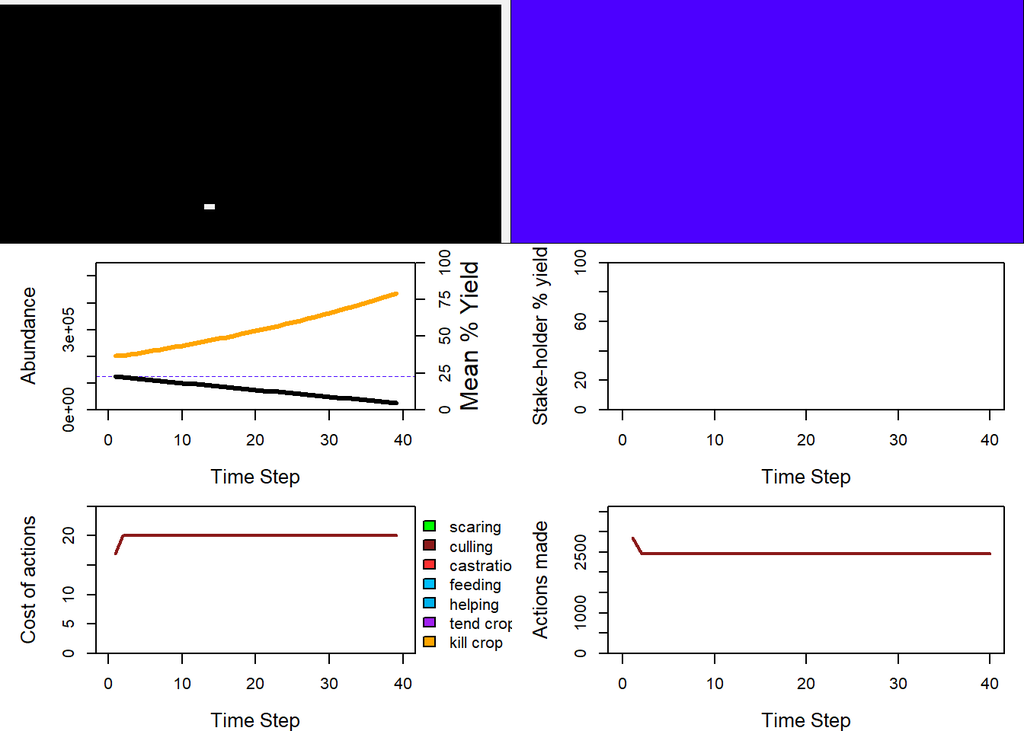

```r
ten_rep_1 <- gmse(
  time_max = 40,
  land_dim_1 = 50,
  land_dim_2 = 50, # landscape is 2500ha or 25km2
  res_movement = 0, # trees don't move
  remove_pr = 0, # Assume no death
  lambda = 0, # assume no growth
  agent_view = 10, # distance (cells) agent can see (currently only manager during obs process)
  agent_move = 50, # distance (cells) agents can travel (mostly affects managers during obs process)
  res_birth_K = 1, # must be positive value, but I want it small i.e. no real recruitment
  res_death_K = 500000, # carrying capacity set to way above starting number of resources
  res_move_type = 0, # 0=no move,
  res_death_type = 1, # 1=density-independent
  observe_type = 0, # 0=density-based sampling
  times_observe = 1, # observes once
  obs_move_type = 1, # uniform in any direction
  res_min_age = 0, # age of resources before agents record/act on them
  res_move_obs = FALSE, # trees don't move
  plotting = FALSE,
  res_consume = 0.02,

  # all genetic algorithm parameters left to default

  move_agents = TRUE, # should agents move at the end of each time step?
  max_ages = 1000, # maximum ages of resources - set very high to reduce natural death
  minimum_cost = 10, # minimum cost of any action in user & manager models - improves precision of manager policy(?)
  user_budget = 1000, # total budget of each stakeholder for performing actions
  manager_budget = 100, # Manager has very little power (10% of user)
  manage_target = 125000, # target resource abundance (same as starting value)
  RESOURCE_ini = 125000, # initial abundance of resources - 50 trees per cell
  culling = TRUE, # culling is only option
  tend_crops = FALSE, # is tending crops on landscape allowed. if TRUE, user can increase yield each time step
  stakeholders = 50, # a village with 50 families
  land_ownership = FALSE, # no land ownership
  manage_freq = 1, # frequency of manager setting policy
  group_think = FALSE # users act independently
)
```

Here we see what I was expecting. The manager uses what little power they have to prevent culling, but is not very effective. Users want to reduce the trees in the cells as they are reducing yield. As trees are culled, the resource population declines and the users yield increases.

The number of trees each user is harvesting per time step after the costs have been increased is 50. In reality probably a bit low as a family can clear more than that in a year (if we are assuming a time step is a year). But fine for now.

### Replicate calls

Here I repeat the above call 10 times and extract summary data. The model set up is the same as above, just using gmse_replicates()

```r
knitr::kable(ten_rep_2_summary)
```

| X | time_step | resources | estimate | cost_culling | cost_unused | act_culling | act_unused | harvested |
| --- | --- | --- | --- | --- | --- | --- | --- | --- |
| 1 | 40 | 22197 | 22103.17 | 20 | 0 | 2500 | 0 | 2500 |
| 2 | 40 | 22898 | 22692.74 | 20 | 0 | 2500 | 0 | 2500 |
| 3 | 40 | 23177 | 22715.42 | 20 | 0 | 2500 | 0 | 2500 |
| 4 | 40 | 23959 | 24467.12 | 20 | 0 | 2500 | 0 | 2500 |
| 5 | 40 | 23211 | 23106.58 | 20 | 0 | 2500 | 0 | 2500 |
| 6 | 40 | 23730 | 23401.36 | 20 | 0 | 2500 | 0 | 2500 |
| 7 | 40 | 23550 | 23690.48 | 20 | 0 | 2500 | 0 | 2500 |
| 8 | 40 | 24333 | 24195.01 | 20 | 0 | 2500 | 0 | 2500 |
| 9 | 40 | 23483 | 23276.64 | 20 | 0 | 2500 | 0 | 2500 |
| 10 | 40 | 23693 | 23458.05 | 20 | 0 | 2500 | 0 | 2500 |

The amount of forest remaining at the end of each simulation is very similar, and the costs and actions do not appear to vary.

## Simulations 3 & 4 (ten_rep_3, ten_rep_4)

Here the model set up is identical to the above, but I have increased the manager budget from 100 (10% of user budget) to 500 (50% of user budget)

### Single call

First I ran a single gmse() call

```
## [1] "Initialising simulations ... "
## [1] "Generation  1 of  40"
## [1] "Generation  2 of  40"
## [1] "Generation  3 of  40"
## [1] "Generation  4 of  40"
## [1] "Generation  5 of  40"
## [1] "Generation  6 of  40"
## [1] "Generation  7 of  40"
## [1] "Generation  8 of  40"
## [1] "Generation  9 of  40"
## [1] "Generation  10 of  40"
## [1] "Generation  11 of  40"
## [1] "Generation  12 of  40"
## [1] "Generation  13 of  40"
## [1] "Generation  14 of  40"
```

[output cut: 26 more lines]

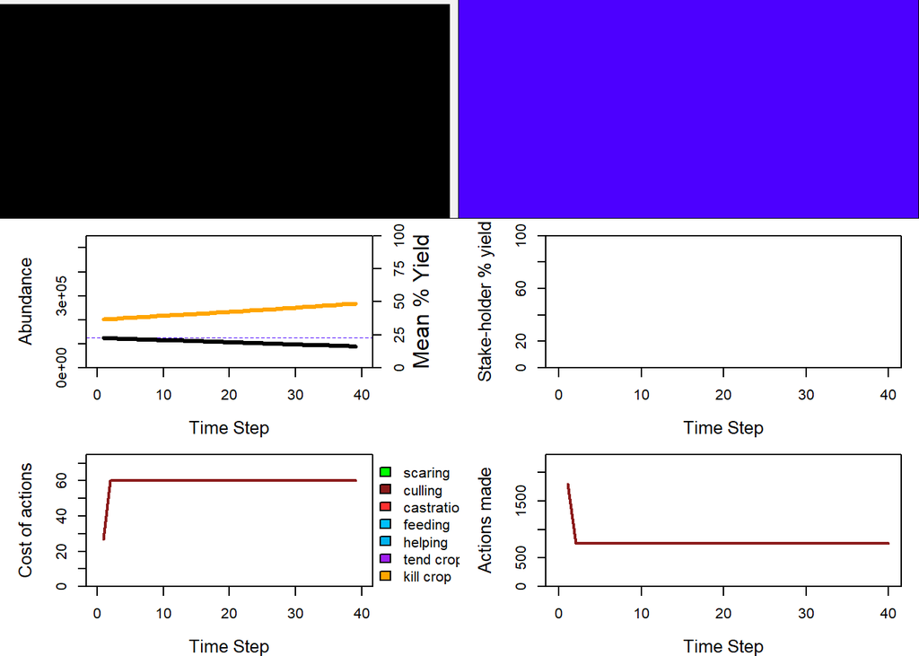

Here we see the loss of trees is much less than before, as the manager has more power to reduce culling by setting higher costs. Users are still able to clear forest though, with 800 trees being lost each time step once the manager has applied their policy.

### Replicate calls

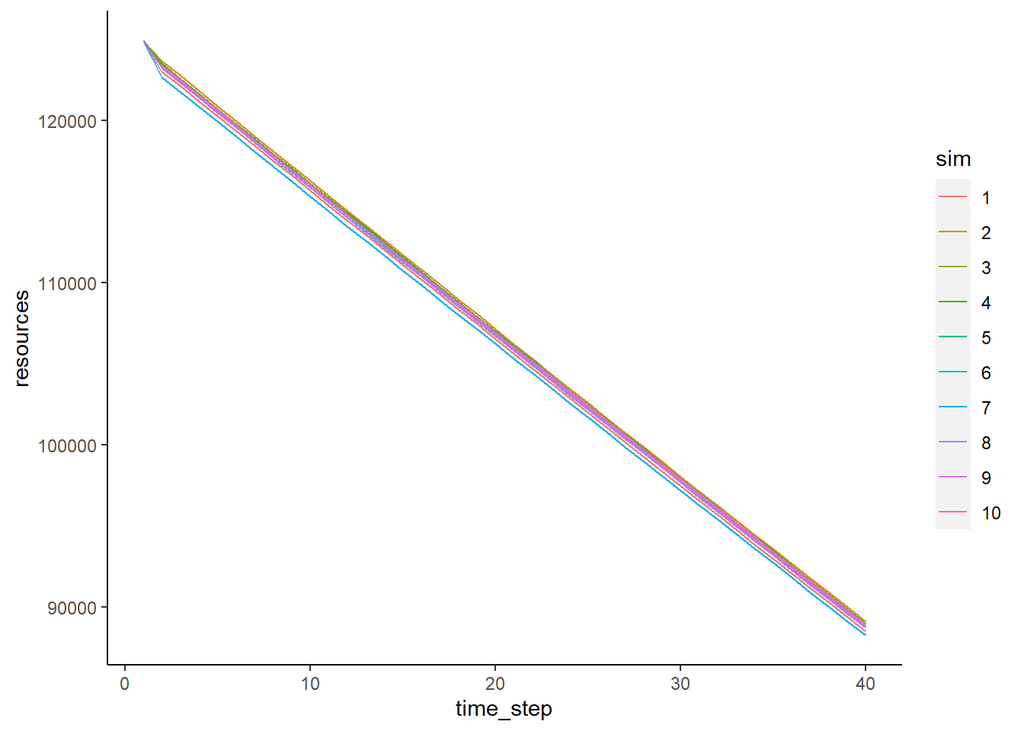

There is not much variation in the decline in resources. I guess this is because the model currently has little flexibility - the manager will always set the highest cost possible as they are trying to maintain all resources, and the users will always try to cull. Furthermore the resources are not reproducing or naturally dying (much), and so there is not much stochasticity in the resource population. Therefore after the inital setting of policy in time step 1, there will be little change between the simulations.

We do however, see some variation in the initial number of culling actions (see below plot)

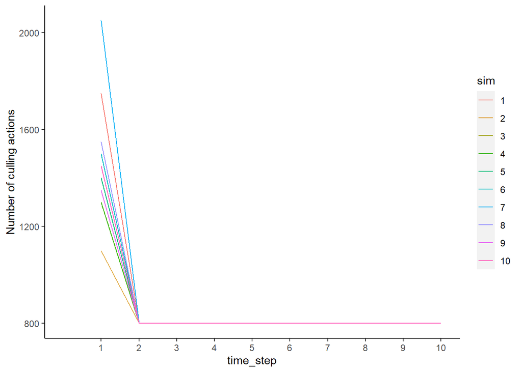

I was not clear what was behind this variation. I thought perhaps it was driven by the fact that, by chance, some users will find themselves on a cell with more resources than othes. Brad has since clarified that this is proabbly due to the genetic algorithm not finding the optimal harvesting solution right away (or the users taking a time step to “learn”).

## Simulation 5 (ten_rep_5)

Here I have used gmse_apply() to dynamically change the managers budget. I have increased the manager budget incrementally over the 40 time steps, in quantities that mean the manager budget exceeds the user budget at some point during the time period.

I would like to see what effects increasing manager budgets have on the actions of the users, and on the resources. I would also like to see how large the manager’s budget needs to be to completely stop all culling.

Model set up:

```r
# manager budget
mb <- 500

# sim_old
ten_rep_5_simold <- gmse_apply(
  res_mod = resource,
  obs_mod = observation,
  man_mod = manager,
  use_mod = user,
  get_res = "FUll",
  land_dim_1 = 50,
  land_dim_2 = 50, # landscape is 2500ha or 25km2
  res_movement = 0, # trees don't move
  remove_pr = 0, # Assume no death
  lambda = 0, # assume no growth
  agent_view = 10, # distance (cells) agent can see (currently only manager during obs process)
  agent_move = 50, # distance (cells) agents can travel (mostly affects managers during obs process)
  res_birth_K = 1, # must be positive value, but I want it small i.e. no real recruitment
  res_death_K = 500000, # carrying capacity set to way above starting number of resources
  res_move_type = 0, # 0=no move,
  res_death_type = 1, # 1=density-independent
  observe_type = 0, # 0=density-based sampling
  times_observe = 1, # observes once
  obs_move_type = 1, # uniform in any direction
  res_min_age = 0, # age of resources before agents record/act on them
  res_move_obs = FALSE, # trees don't move
  plotting = FALSE,
  res_consume = 0.02,

  # all genetic algorithm parameters left to default

  move_agents = TRUE, # should agents move at the end of each time step?
  max_ages = 1000, # maximum ages of resources - set very high to reduce natural death
  user_budget = 1000, # total budget of each stakeholder for performing actions
  manager_budget = mb, # Manager has little power (50% of user)
  manage_target = 125000, # target resource abundance (same as starting value)
  RESOURCE_ini = 125000, # initial abundance of resources - 50 trees per cell
  culling = TRUE, # culling is only option
  tend_crops = FALSE, # is tending crops on landscape allowed. if TRUE, user can increase yield each time step
  stakeholders = 50, # a village with 50 families
)

# matrix for results
ten_rep_5 <- matrix(data=NA, nrow=40, ncol=6)

# loop the simulation. Took 11 mins
for(time_step in 1:40){

  sim_new <- gmse_apply(get_res = "Full", old_list = ten_rep_5_simold, manager_budget=mb)

  ten_rep_5[time_step, 1] <- time_step
  ten_rep_5[time_step, 2] <- sim_new$basic_output$resource_results[1]
  ten_rep_5[time_step, 3] <- sim_new$basic_output$observation_results[1]
  ten_rep_5[time_step, 4] <- sim_new$basic_output$manager_results[3]
  ten_rep_5[time_step, 5] <- sum(sim_new$basic_output$user_results[,3])
  ten_rep_5[time_step, 6] <- mb

  ten_rep_5_simold <- sim_new
  mb <- mb + 20

}

colnames(ten_rep_5) <- c("Time", "Pop_size", "Pop_est", "Cull_cost", "Cull_count",
                         "Manager_budget")
```

Below are some exploratory plots.

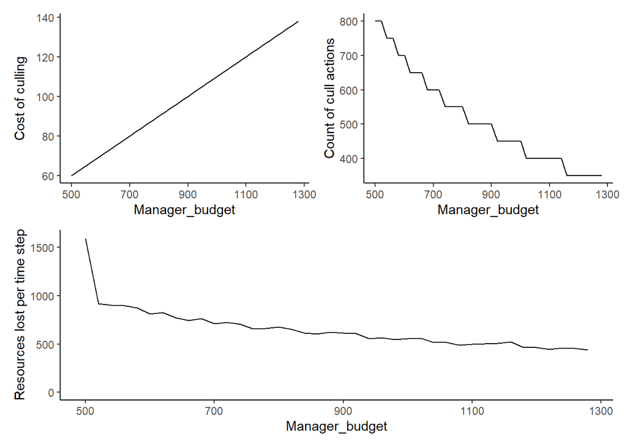

The top left plot shows that there is a linear relationship between the manager’s budget and the cost of culling. In other words, because the manager is trying to stop ALL culling, as soon as they have more budget they will use it to increase the cost of culling.

The plot on the top right I was not quite expecting. There appear to be budget/cost thresholds for increases in culling. This can be seen in the “steps”. For a given manager budget/cull cost, there will be a certain number of culling actions. The number of culling actions will stay the same for a number of time steps, even when the manager budget (and therefore the cost) increases. Then there will be a drop to another level of culling actions. Interestingly, when manager budgets/costs are relatively low, the count of culling actions decrease more quickly in response to increases in cost. Whereas when costs are relatively high, the number of culling actions stay at the same level for longer, despite increases in cost. In other words, the manager’s budget appears to have a larger relative impact when it is lower. I am not sure why this is.

The bottom plot shows how the number of trees lost per time step decreases as manager budgets increase. In other words, as the manager gains power to enact policy, the fewer trees are lost. I guess the stochasticity that can be seen is a result of the changes in the natural die off of trees (otherwise I would expect to see steps, as in the top right plot). The large decrease between time step 1 and 2 will be presumably because the users will cull as much as possible in the beginning before the manager increases the cost in the next time step.

I have clearly not yet found the value of manager budget that is high enough to completely eliminate culling all together. I had assumed that this would be when the manager budget went above the user budget, but this is not the case. I am not yet clear on how the manager budget relates to the cost of actions.

## Simulations 6 & 7 (ten_rep_6, ten_rep_7)

These simulations are exactly the same as the one above, but here I have increased the manager budgets by 50 and 100 in each time step rather than 20. I am trying to see where the threshold is for the manager to have a signficant impact in reducing culling.

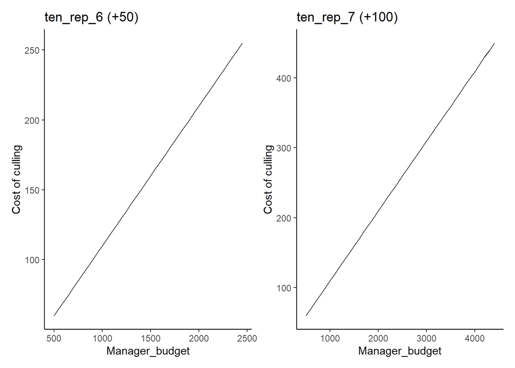

The above plots show that the relationship between the manager’s budget and the cost of culling is still linear regardless of the size of the budget increases, but when the manager has more budget the increases are larger (note the y axis scales).

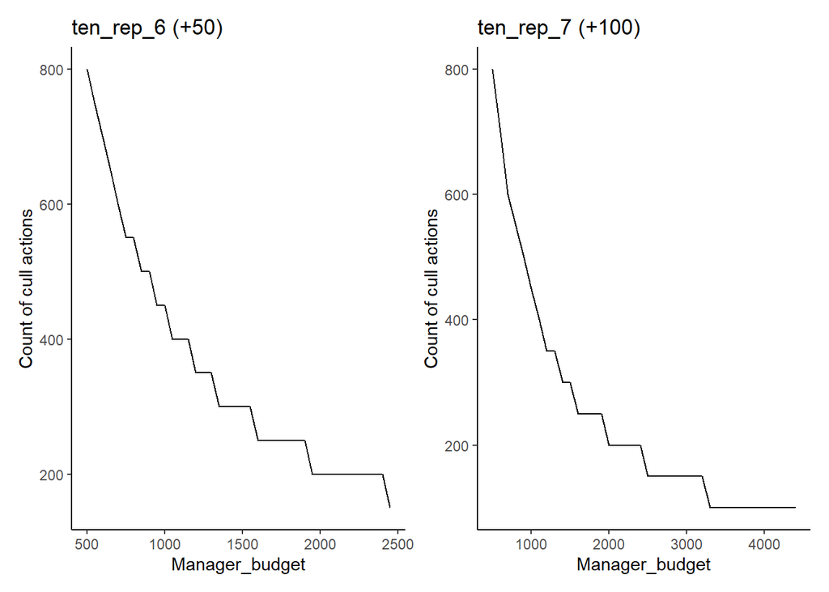

In the above plots we see the same steps (pause in the decline of the cull counts) as we did for ten_rep_5, but they are different shapes. When the manager’s budget is increased by larger increments (right hand plot), the steps don’t appear until the manager’s budget is higher, when compared to the smaller increments simulation (left plot). I guess this is something to do with the smaller incremental increase in the manager’s budget having less of an impact on the ability of the users to cull, and so between any given two time steps, the users may still be able to take the same actions. Whereas when the manager’s budget increase is larger, it is more likely to impact on the users ability to take action from one time step to the next. I am not sure why the steps get larger as the manager’s budget gets larger though.  
Interestingly, I think that ten_rep_7 has identified the manager budget required to force the minimum number of posible culls. The cull count reaches 100 when the manager’s budget is 3300, and then remaines at 100 until the end of the simulation when the manager’s budget is 4400. I guess there is a possibility that it is just another arger step, and that the cull count might continue to fall if the simulation continued. However, a loss of 100 trees per year equates to 0.08% of the population which is pretty good in a Cambodian PA!

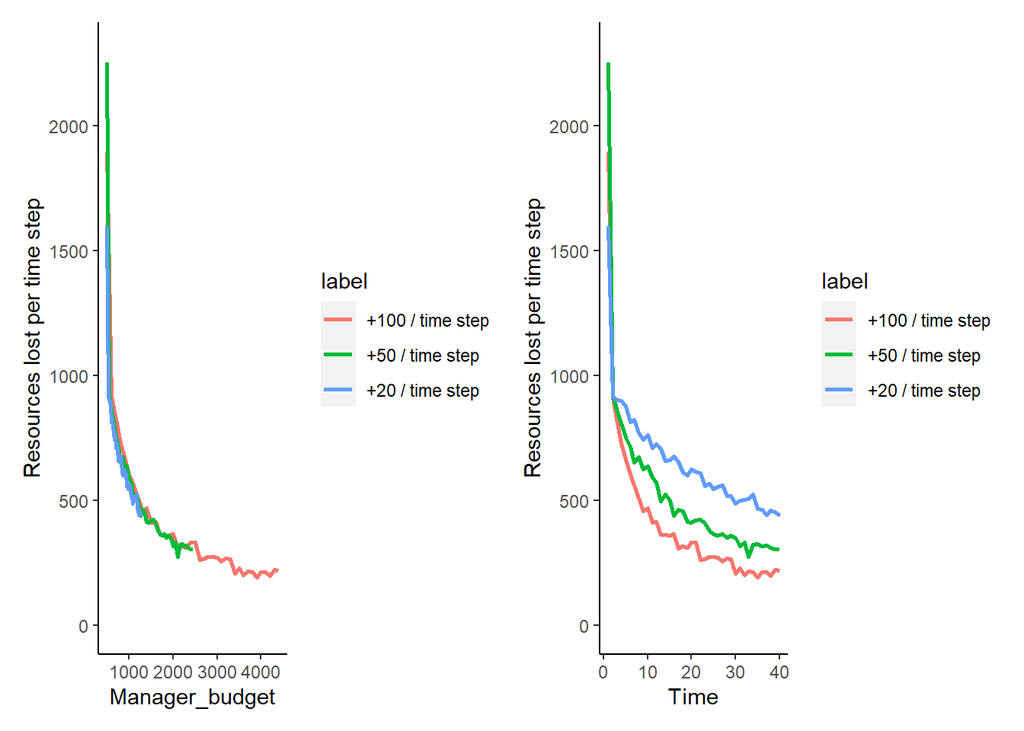

In the above plots I have plotted the number of trees lost per time step against manager budget (left) and time (right) for the three simulations with dynamic manager budgets. All three simulations have very different numbers lost in the first time step, but this is likely due to the variation in number of actions taken in time step 1 resulting from the genetic algorithm still revving up (as Brad explained). The plot on the left shows that the numbers of resources lost per time step decreases as manager budgets increase, which is what I expected. We can see that the blue and green lines stop before they flatten, suggesting that the optimal manager budget for reducing the number of trees lost has not been reached yet. Whereas the pink line looks as though it has flattened out (still with some small fluctuations) suggesting that further manager budget increases will likely have negligible impacts on culling. The plot on the right shows the same thing (the slopes of the lines at time 40 show the green and blue still decreasing, and the pink flattened out), and also that, as I would have expected, the higher the manager budget, the fewer trees get cut down.

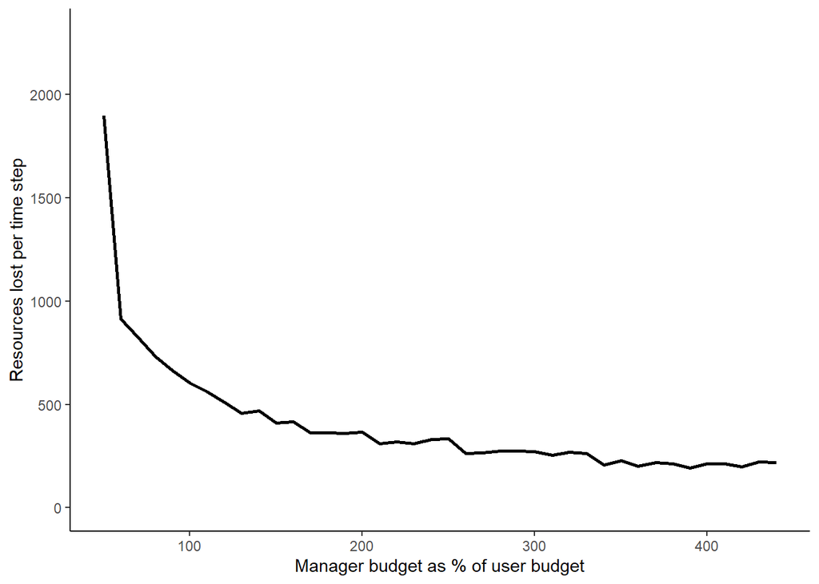

The above plot shows the number of trees lost against the manager’s budget as a percentage of the users’ budget, and we can see that in this scenario, where users do not own land and are therefore trying their hardest to cull, when the the manager’s budget reaches ~300% of the users’ budget, the gains in reducing culling essentially disappear i.e. increasing the manager’s budget further make little different to the number of trees lost.